# Extracting data from PDF files

Alex Sánchez

2022-11-08

# 1 Introduction

Some examples from distinct sources on getting data from PDFs

# 2 Extracting tables with the `tabulizer`package

A very popular package that has been removed from CRAN due to its dependence of JAVA abd ’ rJAVA`

Still in development and available from github: https://github.com/ropensci/tabulizer

## 2.1 Example

```r
library("tabulizer")
f <- system.file("examples", "data.pdf", package = "tabulizer")
out1 <- extract_tables(f)
str(out1)
```

```
## List of 4
##  $ : chr [1:32, 1:10] "mpg" "21.0" "21.0" "22.8" ...
##  $ : chr [1:7, 1:5] "Sepal.Length" "5.1" "4.9" "4.7" ...
##  $ : chr [1:7, 1:6] "" "145" "146" "147" ...
##  $ : chr [1:15, 1] "supp" "VC" "VC" "VC" ...
```

## 2.2 A more elaborated example

This has been adapted from the R-bloggers entry:  
[PDF Scraping in R with tabulizer](https://www.r-bloggers.com/2019/09/pdf-scraping-in-r-with-tabulizer/)

### 2.2.1 Prepare environment and load packages

Install tabulizer if not available

```r
if (!require("remotes")) {
    install.packages("remotes")
}
# on 64-bit Windows
remotes::install_github(c("ropensci/tabulizerjars", "ropensci/tabulizer"), INSTALL_opts = "--no-multiarch")
# elsewhere
remotes::install_github(c("ropensci/tabulizerjars", "ropensci/tabulizer"))
```

Load required libraries

```r
require(tabulizer)
library(tidyverse)
```

### 2.2.2 Extract the desired table from the pdf file

We’ll use the extract_tables() function to pull out each of the tables from the Endangered Species Report. This returns a list of data.frames.

We are interested in the first table - the “Critically Endangered Species”. It is extracted it using the `pluck()` function, an implementation of the “pop” operation on lists that extracts elements from its top, and converted into a `tibble()` (the tidy data frame format).

```r
# myURL <- "https://github.com/Coopmeister/data_science_r_projects/blob/master/endangered_species.pdf"
# myFile <- "endangered_species.pdf"
# download.file(url=myURL, destfile=myFile)

myFile <- "endangered_species.pdf"
endangered_species_scrape <- extract_tables(
    file   = myFile,
    method = "decide",
    output = "data.frame")
endangered_species_raw_tbl <- endangered_species_scrape %>%
    pluck(1) %>%
    as_tibble()
# Show first 6 rows
endangered_species_raw_tbl %>% head() %>% knitr::kable()
```

| X | X.1 | X.2 | X.3 | Critically.Endangered..CR. | X.4 | X.5 | X.6 | X.7 | X.8 |
| --- | --- | --- | --- | --- | --- | --- | --- | --- | --- |
| Year | Mammals | Birds | Reptiles | Amphibians Fishes Insects | Molluscs | Other invertebrates | NA | Plants | Fungi & protists |
| 2019 | 203 | 224 | 303 | 575 549 311 | 658 | 263 | NA | 3,027 | 14 |
| 2018 | 201 | 224 | 287 | 550 486 300 | 633 | 252 | NA | 2,879 | 14 |
| 2017 | 202 | 222 | 266 | 552 468 273 | 625 | 243 | NA | 2,722 | 10 |
| 2016 | 204 | 225 | 237 | 546 461 226 | 586 | 211 | NA | 2,506 | 8 |
| 2015 | 209 | 218 | 180 | 528 446 176 | 576 | 209 | NA | 2,347 | 5 |

### 2.2.3 Clean Up Column Names

“Original” column names have been saved in the first row but we want these to be our table’s column names.

There are distinct ways to do this process but it is worth the pity to do it accurately to avoid trying to set a column name with a missing value or a repetitive one. The article’s author does it in a rather hard but secure way.

```r
# Get column names from Row 1
col_names <- endangered_species_raw_tbl %>%
    slice(1) %>%
    pivot_longer(cols = everything()) %>%
    mutate(value = ifelse(is.na(value), "Missing", value)) %>%
    pull(value)
# Overwrite names and remove Row 1
endangered_species_renamed_tbl <- endangered_species_raw_tbl %>%
    set_names(col_names) %>%
    slice(-1)
# Show first 6 rows
endangered_species_renamed_tbl %>% head() %>% knitr::kable()
```

| Year | Mammals | Birds | Reptiles | Amphibians Fishes Insects | Molluscs | Other invertebrates | Missing | Plants | Fungi & protists |
| --- | --- | --- | --- | --- | --- | --- | --- | --- | --- |
| 2019 | 203 | 224 | 303 | 575 549 311 | 658 | 263 | NA | 3,027 | 14 |
| 2018 | 201 | 224 | 287 | 550 486 300 | 633 | 252 | NA | 2,879 | 14 |
| 2017 | 202 | 222 | 266 | 552 468 273 | 625 | 243 | NA | 2,722 | 10 |
| 2016 | 204 | 225 | 237 | 546 461 226 | 586 | 211 | NA | 2,506 | 8 |
| 2015 | 209 | 218 | 180 | 528 446 176 | 576 | 209 | NA | 2,347 | 5 |
| 2014 | 213 | 213 | 174 | 518 443 168 | 576 | 205 | NA | 2,119 | 2 |

### 2.2.4 Tidy the data

There are a few issues with the data:

1. Remove columns with NAs: Column labelled “Missing” is all NA’s - We can just drop this column
2. Fix columns that were combined: Three of the columns are combined - Amphibians, Fishes, and Insects - We can separate() these into 3 columns
3. Convert to (Tidy) Long Format for visualization: The data is in “wide” format, which isn’t tidy - We can use pivot_longer() to convert to “long” format with one observation for each row
4. Fix numeric data stored as character: The numeric data is stored as character and several of the numbers have commas - We’ll remove commas and convert to numeric
5. Convert Character Year & species to Factor: The year and species columns are character - We can convert to factor for easier adjusting of the order in the ggplot2 visualizations
6. Percents by year: The visualizations will have a percent (proportion) included so we can see which species have the most endangered - We can add proportions by each year

```r
endangered_species_final_tbl <- endangered_species_renamed_tbl %>%

    # 1. Remove columns with NAs
    select_if(~ !all(is.na(.))) %>%

    # 2. Fix columns that were combined
    separate(col  = `Amphibians Fishes Insects`,
             into = c("Amphibians", "Fishes", "Insects"),
             sep  = " ") %>%

    # 3. Convert to (Tidy) Long Format for visualization
    pivot_longer(cols = -Year, names_to = "species", values_to = "number") %>%

    # 4. Fix numeric data stored as character
    mutate(number = str_remove_all(number, ",")) %>%
    mutate(number = as.numeric(number)) %>%

    # 5. Convert Character Year & species to Factor
    mutate(Year = as_factor(Year)) %>%
    mutate(species = as.factor(species)) %>%

    # 6. Percents by year
    group_by(Year) %>%
    mutate(percent = number / sum(number)) %>%
    mutate(label = scales::percent(percent)) %>%
    ungroup()
# Show first 6 rows
endangered_species_final_tbl %>% head() %>% knitr::kable()
```

| Year | species | number | percent | label |
| --- | --- | --- | --- | --- |
| 2019 | Mammals | 203 | 0.0331320 | 3.31% |
| 2019 | Birds | 224 | 0.0365595 | 3.66% |
| 2019 | Reptiles | 303 | 0.0494532 | 4.95% |
| 2019 | Amphibians | 575 | 0.0938469 | 9.38% |
| 2019 | Fishes | 549 | 0.0896034 | 8.96% |
| 2019 | Insects | 311 | 0.0507589 | 5.08% |

### 2.2.5 Summarize and Visualize the data

The chances here are infinite, but, why not remember that the reason why we are doing this with R is that we may want to end up analyzing the data?

#### 2.2.5.1 Summary visualization

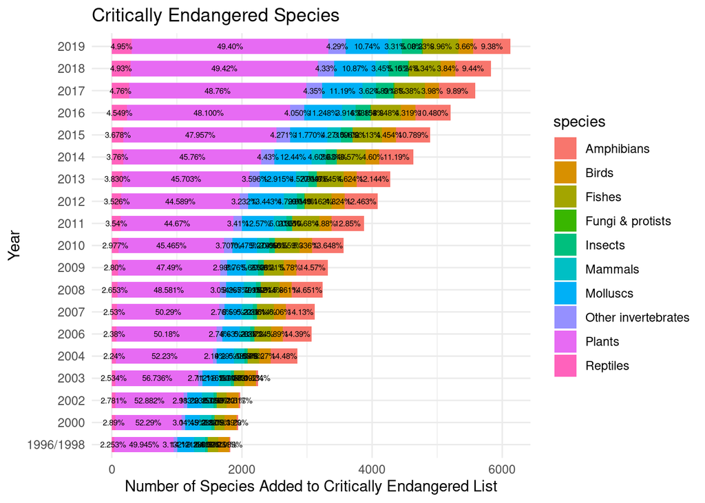

```r
endangered_species_final_tbl %>%
    mutate(Year = fct_rev(Year)) %>%

    ggplot(aes(x = Year, y = number, fill = species)) +

    # Geoms
    geom_bar(position = position_stack(), stat = "identity", width = .7) +
    geom_text(aes(label = label), position = position_stack(vjust= 0.5), size = 2) +
    coord_flip() +

    # Theme
    labs(
        title = "Critically Endangered Species",
        y = "Number of Species Added to Critically Endangered List", x = "Year"
    ) +
    theme_minimal()
```

#### 2.2.5.2 Trends Over Time by Species

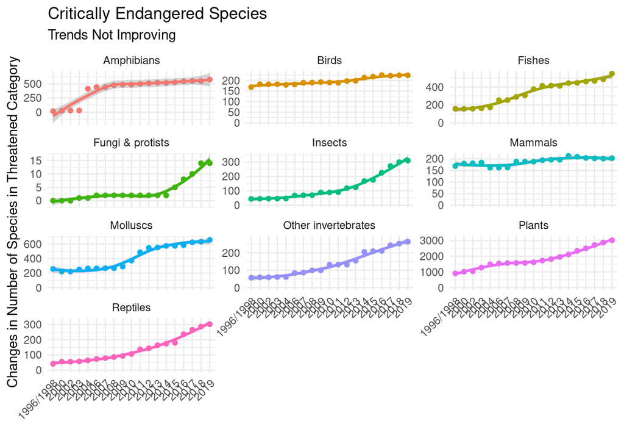

```r
endangered_species_final_tbl %>%
    mutate(Year = fct_rev(Year)) %>%

    # Geom
    ggplot(aes(Year, number, color = species, group = species)) +
    geom_point() +
    geom_smooth(method = "loess") +
    facet_wrap(~ species, scales = "free_y", ncol = 3) +

    # Theme
    expand_limits(y = 0) +
    theme_minimal() +
    theme(legend.position = "none",
          axis.text.x = element_text(angle = 45, hjust = 1)) +
    labs(
        title = "Critically Endangered Species",
        subtitle = "Trends Not Improving",
        x = "", y = "Changes in Number of Species in Threatened Category"
    )
```

# 3 Extracting text with `pdftools`

- Imagine we need to convert a pdf file from the “BOLETÍN OFICIAL DEL REGISTRO MERCANTIL” https://www.boe.es/borme/dias/2022/10/05/pdfs/BORME-A-2022-191-08.pdf
- Start downloading the file on which we are interested.

```r
myURL <- "https://www.boe.es/borme/dias/2022/10/05/pdfs/BORME-A-2022-191-08.pdf"
myFilename <-"BORME-A-2022-191-08.pdf"
download.file(url=myURL, destfile=myFilename)
```

- PDF file is extracted as a vector of character strings
- Each string contains a page of the document
- Once the data is available it may/must be cleaned using R text analysis capabilities

```r
library(pdftools)
txt <- pdf_text(myFilename)
class(txt)
```

```
## [1] "character"
```

```r
length(txt)
```

```
## [1] 22
```

```r
cat(txt[1])
```

```
##                      BOLETÍN OFICIAL DEL REGISTRO MERCANTIL
## Núm. 191                                           Miércoles 5 de octubre de 2022                                               Pág. 46120
##
##
##
##
##                                          SECCIÓN PRIMERA
##                                                         Empresarios
##                                                          Actos inscritos
##
##                                                             BARCELONA
##
##
##      438642 - AUTH0 LTD SUCURSAL EN ESPAÑA.
##      Fe de erratas: En el BORME no.8/2022 y con referencia 13527 SE OMITIO LA PUBLICACION DE "OTROS ACTOS: CONSTANCIA
##      DE LA COMPOSICION DEL ORGANO DE ADMINISTRACION DE LA SOCIEDAD MATRIZ ". Datos registrales. T 47748 , F 215, S 8,
##      H B 561206, I/A 2 ( 5.01.22).
##
##      438643 - SISTEMAS DE AUTOGAS DE ESPAÑA S.L.
##      Fe de erratas: En el BORME no.74/2022 y con referencia 144233 SE OMITIOLA PULICACION DEL ACTO DE AUMENTO DE
##      CAPITAL EN "3100,00 " SIENDO EL CAPITAL RESULTANTE DE " 6100,00 ". Datos registrales. T 47301 , F 195, S 8, H B 547852,
##      I/A 4 (27.03.20).
##
##      438644 - PROMVIAS XXI SA.
##      Nombramientos. CONS.DEL.MAN: ANGULO CORDERO RAFAEL. Fe de erratas: En el BORME no.81/2015 y con referencia
##      178510 SE RECTIFICA EN CUANTO A LA OMISION DEL NOMBRAMIENTO DE RAFAEL ANGULO CORDERO EN EL CARGO DE
##      CONS.DEL.MAN. Datos registrales. T 38215 , F 199, S 8, H B 318461, I/A 17 (22.04.15).
##
##      438645 - DRAGON STATE SL.
##      Fe de erratas: En el BORME no.93/2007 y con referencia 268024 DONDE SE LEE COMO ADMINISTRADOR "RAMOS HIRSCH",
##      DEBE LEERSE: "RAMOS HIRSCH, MARCOS". Datos registrales. T 39534 , F 11, S 8, H B 349398, I/A 1 (25.04.07).
##
##      438646 - SOLUNUBE S.L.
##      Fe de erratas: En el BORME no.172/2022 y con referencia 406104 SE RECTIFICA EL NOMBRAMIENTO DEL REPRESENTATE
##      DEL ADMINISTRADOR, DONDE SE LEE "ROBLES GARRIDO, MARIA DOLORES", DEBE LEERSE "ROBLES GARRIDO, MARIA".
##      Datos registrales. T 48443 , F 193, S 8, H B 584041, I/A 1 ( 1.09.22).
##
##      438647 - PROMOCIONS GLEZER 2004 SL.
##      Fe de erratas: En el BORME no.176/2005 y con referencia 393491 SE COMETIO ERROR EN EL PRIMER APELLIDO DE UNA DE
##      LAS ADMINISTRADORAS SOLIDARIAS NOMBRADAS, SIENDO SU IDENTIDAD CORRECTA "EVA FARRERAS CASTELLVI".
```

[output cut: 17 more lines]

```
##
##
##      (18.12.19).
##                                                                                                                                          cve: BORME-A-2022-191-08
##
##
##
##
##      438651 - SISTEMAS DE AUTOGAS DE ESPAÑA S.L.
##      Ampliación de capital. Capital: 3.100,00 Euros. Resultante Suscrito: 6.100,00 Euros. Datos registrales. T 47301 , F 195, S 8, H B
##      547852, I/A 4 (27.03.20).
##
##      438652 - AUTH0 LTD SUCURSAL EN ESPAÑA.
##      Otros conceptos: CONSTANCIA DE LA COMPOSICION DEL ORGANO DE ADMINISTRACION DE LA SOCIEDAD MATRIZ. Datos
##      registrales. T 47748 , F 215, S 8, H B 561206, I/A 2 ( 5.01.22).
```

## 3.1 Getting more information

# 4 Some Resources

-[PDF Scraping in R with tabulizer](https://www.r-bloggers.com/2019/09/pdf-scraping-in-r-with-tabulizer/)

-[Converting PDFs to txt files with R](https://ladal.edu.au/pdf2txt.html) -[Getting your .pdfs into R](https://alexluscombe.ca/post/r-pdftools/) -[Parsing your .pdfs in R](https://alexluscombe.ca/blog/parsing-your-.pdfs-in-r/)

-https://learningactors.com/how-to-extract-and-clean-data-from-pdf-files-in-r/ -[Scrape tables from PDF](https://crimebythenumbers.com/scrape-table.html)